# STAA57 Final Project Report

Brian Lin, Ian Gu, Minyi Ma, Navin Chandradat

## Introduction

(*Description of questions that are being investigated*)

### How fast will you be able to recoup your investment in post-secondary education - money approach?

(*Description of data used to answer the questions*)

### Main data used:

Lfs2013: Labour force survey, 2013 The Labour Force Survey is a monthly survey in which citizens of Canada are asked to respond to several questions which measure the state of the labour market in Canada. Among the information extracted from the survey are statistics like the employment status of citizens, the income of their jobs etc. Cis2013: Canadian Income Survey, 2013 The Canadian Income Survey provides information related to each surveyed Canadian citizen’s job status such as their age group, education level, and unemployment time length. We will be using this data to extrapolate the unemployment condition.

##### Group by:

- educ90: Highest educational attainment (1990- )
- This will be the grouping variable that helps identify whether people finish university in lfs.
- age_12: Five-year age group of respondent in lfs
- This will be the grouping variable that shows unemployment rate and income difference through different age groups.
- HLEV2G: Highest level of education
- This will be the grouping variable that helps identify whether people finish university in cis.

##### Exclusion:

- FLLPRTP: Full-time or part-time student during refyear
- This binary variable will be used to filter out all current full-time students, to make sure they won’t effect the unemployment rate.

##### Independent variables to consider:

For income: * hrlyearn: Usual hourly wages * age_12: Five-year age group of respondent in lfs （for this variable mainly use the combination of hrlyearn and it）

For unemployment: *lfsstat: Labour force status* age_12: Five-year age group of respondent in lfs （for this variable mainly use the combination of lfsstat and it * WKSUEM: All persons aged 16 to 69 and persons aged 70 and over who worked during the reference year

## Analysis

(*Main body of analysis, containing data summaries (tables/plots), statistical analyses (estimations, tests), and modelling (regression, classification)* ) ###Analysis upon income. (*Plots should be created in R, and not imported from file*)

```r
ngs = read.csv("ngs.csv")
cis = read.csv("cis.csv")
lfs = read.csv("lfs.csv")
```

> In this part, we want to see if attending post secondary education, or specifically, university education can lead to a higher income.

```r
#the highest education effect on 1990 later
lfs_90 = lfs %>% mutate(educ90 = factor(educ90, levels=0:6, labels = c("N", "N", "N", "NF", "T", "T", "T"))) %>% mutate(pick = is.na(educ90)) %>% filter(pick == FALSE) %>% select(1:6)
```

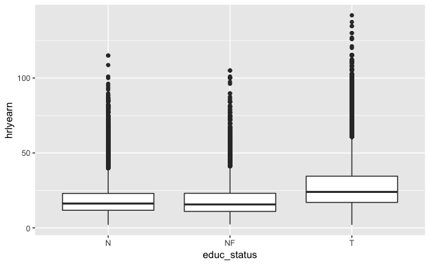

```r
library(ggplot2)
#the highest education effect on 1990 later
lfs_90 = lfs %>% mutate(educ90 = factor(educ90, levels=0:6, labels = c("N", "N", "N", "NF", "T", "T", "T"))) %>% mutate(pick = is.na(educ90)) %>% filter(pick == FALSE) %>% select(1:6)
lfs_90 %>% ggplot() + geom_boxplot(aes(x = educ90, y=hrlyearn)) + xlab("educ_status")
```

> Firstly we do a basic comparison of the hourly earning between the highest education level. The data gives 7 different types of education level, from entry level to the Master degree. We choose the education data of 1990 later to make sure its up to date and devide these people into three groups showing the level they engage in the post secondary education. Based on the boxplot, it is clear that in average, most people who obatained a university degree are tend to have a higher hourly income. Also, the highest income that group of people can reach are much higher that two other groups. Another thing that can be discovered from the graph is that though highly closed, the *NF* group(people who does attend but not finish the post secondary education), however, have the lowest income on average, and the also the highest income of that group is the lowest among that of the three groups. Which may shows that the paid back of taking university eucation is also related to whether taking the complete 4 years or more. To make it easier to test for different age, we now combine NF and N(since their result are really close considering hrlyearn)

```r
lfs_90_N = lfs %>% mutate(educ90 = factor(educ90, levels=0:6, labels = c("N", "N", "N", "N", "T", "T", "T"))) %>% mutate(pick = is.na(educ90)) %>% filter(pick == FALSE) %>% select(1:6) %>% filter(educ90 == "N")
lfs_90_T = lfs %>% mutate(educ90 = factor(educ90, levels=0:6, labels = c("N", "N", "N", "N", "T", "T", "T"))) %>% mutate(pick = is.na(educ90)) %>% filter(pick == FALSE) %>% select(1:6) %>% filter(educ90 == "T")
N_age = lfs_90_N %>% group_by(age_12) %>% summarise(avg_income_N = mean(hrlyearn, na.rm = TRUE))
T_age = lfs_90_T %>% group_by(age_12) %>% summarise(avg_income_T = mean(hrlyearn, na.rm = TRUE))
left_join(T_age, N_age, by = "age_12") %>% mutate(diff = avg_income_T - avg_income_N) %>% knitr::kable()
```

| age_12 | avg_income_T | avg_income_N | diff |
| --- | --- | --- | --- |
| 1 | 12.42850 | 11.28347 | 1.145028 |
| 2 | 16.65683 | 14.54037 | 2.116466 |
| 3 | 23.46788 | 19.28354 | 4.184342 |
| 4 | 26.15649 | 20.66083 | 5.495661 |
| 5 | 28.00882 | 21.23245 | 6.776367 |
| 6 | 28.52167 | 21.34723 | 7.174446 |
| 7 | 28.98427 | 21.72887 | 7.255399 |
| 8 | 29.30186 | 22.08632 | 7.215547 |
| 9 | 29.08903 | 21.73451 | 7.354519 |
| 10 | 27.85430 | 20.39663 | 7.457671 |
| 11 | 25.44978 | 18.13822 | 7.311554 |
| 12 | 22.99443 | 17.64974 | 5.344686 |

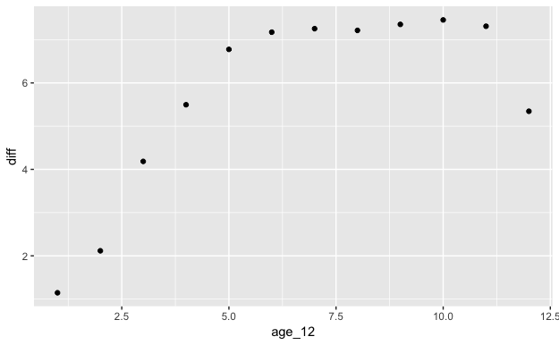

```r
left_join(T_age, N_age, by = "age_12") %>% mutate(diff = avg_income_T - avg_income_N) %>% ggplot(aes(x = age_12, y = diff)) + geom_point( )
```

> Based on the data, we group the peoples age for 5 years each. It is clear that for all age group, owning a secondary eduaction degree is a guarantee of higher hourly earn. For more specific apporach, we then look at the difference of the difference of hourly earning between people who have degree and who not. The difference keep increasing till it reach the highest pointat group10, age between 60-64. This is mainly showing that the effect of posy secondary degree will become larger as age grows. While the data decrease after group10, is mainly due to the retirement and also back to years ago the post-secondary are not that necessary in 20th century.

#### Analysis upon unemployment

(*R output tables can be converted to .html with* `knitr::kable()`) >Secondly, we want to see if the university offer people higher chance to get a job, which means will the unemployment rate be lower or will the unemployment period will be shorter if for the population who does finsih their university education.

```r
lfs_N = lfs %>% filter(lfsstat != 6) %>%mutate(educ90 = factor(educ90, levels=0:6, labels = c("N", "N", "N", "N", "T", "T", "T"))) %>% mutate(pick = is.na(educ90)) %>% filter(pick == FALSE) %>% select(1:6) %>% filter(educ90 == "N") %>% mutate(lfsstat = (lfsstat >= 3)) %>% group_by(age_12) %>% summarise(unemploy_rate_N = mean(lfsstat))
lfs_T = lfs %>% filter(lfsstat != 6) %>%mutate(educ90 = factor(educ90, levels=0:6, labels = c("N", "N", "N", "N", "T", "T", "T"))) %>% mutate(pick = is.na(educ90)) %>% filter(pick == FALSE) %>% select(1:6) %>% filter(educ90 == "T") %>% mutate(lfsstat = (lfsstat >= 3)) %>% group_by(age_12) %>% summarise(unemploy_rate_T = mean(lfsstat))
left_join(lfs_T,lfs_N, by = "age_12") %>% mutate(diff = unemploy_rate_N - unemploy_rate_T )%>% knitr::kable()
```

| age_12 | unemploy_rate_T | unemploy_rate_N | diff |
| --- | --- | --- | --- |
| 1 | 0.1437632 | 0.1912258 | 0.0474625 |
| 2 | 0.0808928 | 0.1271796 | 0.0462868 |
| 3 | 0.0597391 | 0.1097769 | 0.0500378 |
| 4 | 0.0507891 | 0.0854122 | 0.0346231 |
| 5 | 0.0443121 | 0.0804035 | 0.0360915 |
| 6 | 0.0427999 | 0.0790802 | 0.0362803 |
| 7 | 0.0467587 | 0.0737010 | 0.0269423 |
| 8 | 0.0479578 | 0.0702760 | 0.0223182 |
| 9 | 0.0530367 | 0.0723387 | 0.0193020 |
| 10 | 0.0626657 | 0.0829526 | 0.0202868 |
| 11 | 0.0528113 | 0.0661092 | 0.0132979 |
| 12 | 0.0353126 | 0.0301801 | -0.0051325 |

> We first estimate the unemployment rate for both group through age group. The “unemploy_rate_T” stands for the rate for people attend univeristy and “unemploy_rate_N” stands for those who not. Clearly, most of the diff is positive, which means that people who didn’t have university degree will tend to have higher unemployment rate. Also, there is a trend showing that with ages grow, the difference tend to be smaller, which reveals that the university education are becoming more important as time goes.

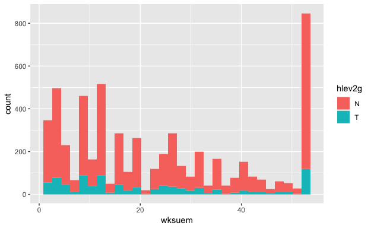

```r
cis_new = cis %>% filter(hlev2g %in% c(1,2,3,4)) %>% mutate(hlev2g = factor(hlev2g, levels=1:4, labels = c("N", "N", "N", "T"))) %>% filter(wksuem %in% c(0:52))
cis_new %>% filter(wksuem != 0) %>% ggplot(aes(x = wksuem, fill = hlev2g))+geom_histogram()
```

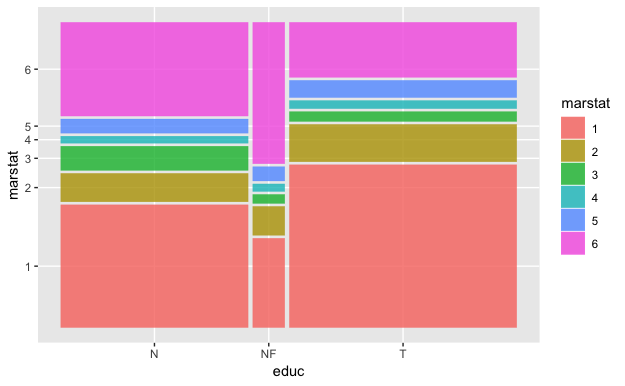

```r
library(ggmosaic)
lfs_90 %>% mutate(marstat = factor(marstat)) %>% ggplot() + geom_mosaic(aes(x = product(educ90), fill = marstat)) + xlab("educ") + ylab("marstat")
```

> Finally, we want to see if having education have any effects on people’s daily life. With the mosaic graph, we can easily see that the education can lead to a higher rate of married.

## Appendix

(*Everything here does not count towards page limit*)